# The Gender Wage Gap Across Occupations

Anni and Daniel

## Motivation

The gender wage gap is well-documented at the aggregate level — but **the story is far more nuanced across occupations and industries**.

- Does the gap widen in male-dominated fields and narrow in female-dominated ones?
- Are some sectors converging toward parity while others stagnate?
- What structural factors — industry, workforce size, gender composition — predict the size of the gap?

> “The question isn’t just whether a gap exists, but where it’s largest, and why.”

## Project Overview

**Objective:** Analyze occupation-level variation in the gender wage gap and identify key predictors of earnings disparities.

**Data:** Occupation-level panel dataset from the Bureau of Labor Statistics via TidyTuesday

| Feature | Detail |
| --- | --- |
| Years covered | 2013–2016 |
| Observations | 2,088 |
| Key variables | Earnings, gender composition, industry |

**Methods:** Multiple Linear Regression · Lasso/Ridge Regression · K-means Clustering

## Two Outcome Variables

We constructed and used **two complementary measures** of the wage gap:

**1. `wage_gap`** — Dollar difference between male and female median earnings (male − female)

- Captures the absolute magnitude of disparity
- Expected to be positive for most occupations (men earn more)
- Useful for understanding real-dollar impact

**2. `wage_percent_of_male`** — Female median earnings as a percentage of male earnings

- Captures the relative disparity
- 100 = perfect parity; values below 100 = women earn less
- Allows fair comparisons across high- and low-wage occupations

## Data Cleaning: Two Analytic Approaches

A substantial number of `wage_percent_of_male` values were missing — flagged by TidyTuesday’s author because those occupations had **small sample sizes**, making the metric unreliable.

We addressed this with **two parallel datasets**:

|  | Approach 1: Complete Cases | Approach 2: Imputed |
| --- | --- | --- |
| Strategy | Dropped all occupations with any missing `wage_percent_of_male` | Retained all; recomputed missing values from `total_earnings_female / total_earnings_male × 100` |
| Trade-off | Higher reliability, reduced sample | Larger sample; captures rare or niche occupations |

We ran **all key analyses on both** and compared results for robustness.

## Key Variables

**Response Variables:**

- `wage_gap` — male minus female median earnings (dollars)
- `wage_percent_of_male` — female earnings as % of male earnings

**Key Predictors:**

- `percent_female` — share of the occupation that is female
- `total_workers` — total estimated full-time workers (log-transformed in models)
- `major_category` — broad industry sector (8 categories)
- `minor_category` / `occupation` — finer-grained job classifications
- `year` — 2013 through 2016 (used as fixed effects)

## Summary Statistics

[figure not shown]

- Median `wage_percent_of_male` ≈ **84%** — women earn roughly 84 cents per male dollar across occupations
- Median `wage_gap` ≈ **$8,600** in annual earnings
- Wide variation: `percent_female` ranges from near 0% to near 100%

## EDA: Wage Gap Trends by Industry

[figure not shown]

- **Management, Business** **and Financial** and **Production, Transportation, and Material Moving** show the largest persistent gaps
- Trends are relatively flat over the years

## EDA: Wage Gap Trends by Industry

[figure not shown]

- **Management, Business** **and Financial** and **Production, Transportation, and Material Moving** still show the largest persistent gaps
- Trends are relatively more volatile over the years

## EDA: Feminization and Wage Parity

[figure not shown]

## EDA: Feminization and Wage Parity

[figure not shown]

- No observable association
- The extent of disparities between occupations within the Natural Resources, Construction and Maintenance sector seems to to vary greatly

## Modeling: Linear Regression

We regressed `wage_percent_of_male` on key predictors using the complete-cases dataset:

$$\widehat{\text{wage\%}} = \beta_0 + \beta_1(\text{percent\_female}) + \beta_2\log(\text{total\_workers}) + \beta_3(\text{year FE}) + \beta_4(\text{industry FE})$$

## Modeling: Lasso & Ridge Regression

To handle multicollinearity among the many occupation/industry predictors and identify the most important features, we applied **regularized regression**:

[figure not shown]

## Modeling: K-Means Clustering

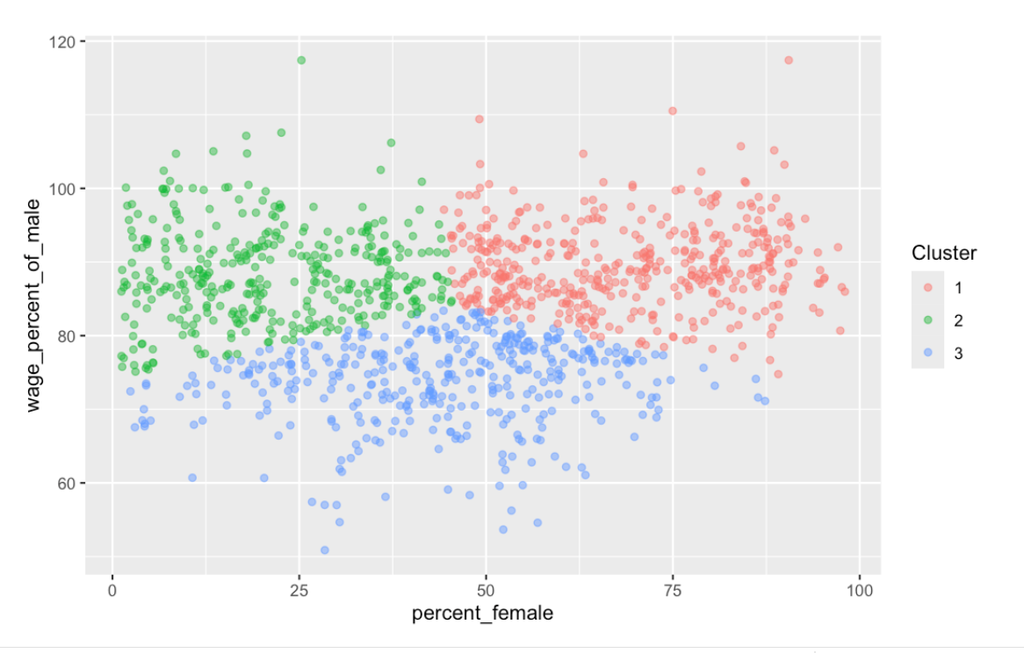

To discover **natural groupings** of occupations beyond the predefined industry categories, we applied K-means clustering.

**Features used for clustering:** - `percent_female` - `wage_percent_of_male` (or `wage_gap`) - `log(total_workers)`

| Cluster | Profile | Example Occupations |
| --- | --- | --- |
| 1 | High feminization, small wage gap | Office and Administrative Support |
| 2 | Low feminization, small wage gap | - |
| 3 | Mixed composition, high wage gap | - |

Clustering revealed that industry category alone does not capture much of the structure of wage disparity

## Findings & Results

**1.** Across 2013–2016, the wage disparity persisted

**2.** More feminized occupations tend to have smaller wage parity, but the effect varies considerably by sector.

**3. Management, Business** **and Financial** and **Production, Transportation, and Material Moving** show the largest persistent gaps

4.Clustering revealed that industry category alone does not capture much of the structure of wage disparity

**5. Lasso** regularization retains `percent_female` as the most important predictors

## Limitations

**Data constraints:**

- Coverage only through 2013–2016 — results may not reflect later labor market shifts
- Indutry sector and occupation-level aggregates mask variation by firm, region, education, or experience

**Methodological constraints:**

- We observe correlation, not causation — we cannot claim `percent_female` causes wage parity to change
- Our regressions has a low r^2 and our K-means clusters results are even, and fif not illustrate clear clusterings

## Future Work

- Include data over longer time spans to build a clearer time series.
- Incorporate individual-level microdata to better account for education, experience, and firm size.
- Broader direction: How does occupational segregation, beyond simple gender composition, contribute to overall wage gaps?